# Deconvolução de misturas celulares no conjunto Visium `stxBrain` com RCTD

Flávio Gabriel Carazza-Kessler

2026-09-04

# 1 Visão geral

Esta vinheta demonstra como estimar misturas de tipos celulares na seção anterior do cérebro de camundongo `stxBrain` com o método Robust Cell Type Decomposition (RCTD), usando o Seurat 5.5.1 e a versão 2.2.1 do pacote `spacexr` disponível no GitHub (Cable et al. 2022).

O objeto espacial será obtido diretamente pelo pacote `SeuratData`, usando a seção `anterior1` (Hao et al. 2024). Nenhum objeto espacial previamente processado será reutilizado. Essa separação é importante porque o RCTD modela contagens brutas de expressão e, por padrão, exige valores inteiros. Matrizes normalizadas, como as produzidas por `NormalizeData()` ou `SCTransform()`, não devem ser fornecidas como entrada do método.

Ao final do roteiro, você será capaz de:

1. explicar por que a deconvolução requer uma referência single-cell anotada;
2. obter do `SeuratData` as contagens brutas e as coordenadas do Visium;
3. preparar a referência single-cell do córtex de camundongo do Allen Institute (Tasic et al. 2016);
4. executar o RCTD;
5. inspecionar e visualizar as proporções estimadas; e
6. acrescentar ao objeto Seurat a classificação e os tipos celulares atribuídos pelo RCTD.

# 2 Fundamentos conceituais

Um spot do Visium é maior que uma única célula e pode capturar RNA proveniente de vários tipos celulares. O RCTD aprende perfis de expressão a partir de dados anotados de scRNA-seq (single-cell) ou snRNA-seq (single-nucleus), corrige diferenças entre as plataformas da referência e da amostra espacial e estima a contribuição de cada tipo celular em cada spot (Cable et al. 2022).

A análise possui duas entradas e uma saída principal:

| Componente | Objeto utilizado | Informação necessária |
| --- | --- | --- |
| Amostra espacial | `stxBrain`, seção `anterior1`, carregada por `SeuratData` | contagens brutas de genes por spots e coordenadas dos spots |
| Referência single-cell | córtex de camundongo do Allen Institute | contagens brutas de genes por células e um rótulo de tipo celular por célula |
| Resultado do RCTD | objeto da classe `RCTD` | classificação e pesos de até dois tipos celulares por spot |

O `spacexr` oferece três modos:

- `doublet`: ajusta no máximo dois tipos celulares por spot;
- `multi`: ajusta até `MAX_MULTI_TYPES` tipos celulares por spot; e
- `full`: não impõe um limite fixo ao número de tipos celulares.

Usaremos o modo `doublet`, por ser mais leve. No modo `doublet`, o RCTD atribui um ou dois tipos celulares a cada spot. Isso é uma simplificação do modelo e não significa que um spot Visium contenha, biologicamente, no máximo duas células ou dois tipos celulares.

# 3 Antes de começar

## 3.1 Requisitos computacionais

- R e RStudio;
- no mínimo 20 GB de memória RAM, embora uma quantidade maior seja recomendada;
- acesso à internet para a primeira instalação dos pacotes e dos dados; e
- múltiplos núcleos de CPU para reduzir o tempo de execução, quando disponíveis.

Como referência de desempenho, a execução validada para a etapa de cálculo do algortimo do RCTD levou 14,22 minutos em um servidor de alta performance com 160 GB de RAM e 30 núcleos de CPU disponíveis para processamento paralelo. O tempo pode variar bastante de acordo com o equipamento, a carga do servidor e o número de tipos celulares da referência. O parâmetro `max_cores` controla o paralelismo na CPU; esta análise não utiliza aceleração por GPU.

Além disso, a paralelização empregada neste fluxo está disponível apenas em Linux e macOS. No Windows, `max_cores` deve ser igual a 1, o que pode aumentar consideravelmente o tempo de processamento. Diferentemente das demais, esta vinheta inclui figuras previamente geradas para que o fluxo possa ser acompanhado mesmo quando não for possível executar a análise completa durante o curso.

Durante o curso, recomenda-se executar os blocos de código na ordem em que aparecem. Assim, cada objeto intermediário pode ser conferido antes de prosseguir.

## 3.2 Estrutura esperada das pastas

O conjunto `stxBrain` não precisa ser copiado para o repositório: ele é instalado pelo `SeuratData` na biblioteca de pacotes do R. O único arquivo de entrada local é `allen_cortex.rds`, que será baixado mais adiante e armazenado em `data/`. Os resultados serão gravados em `resultados/` e as figuras em `imagens/`.

```
Curso_ST/
|-- data/
|   `-- allen_cortex.rds
|-- imagens/
`-- resultados/
```

# 4 Conferir os pacotes necessários

A instalação de todos os pacotes e de suas dependências está centralizada em [Configuracao_do_ambiente_RStudio.Rmd](https://flaviogckessler.github.io/Curso_ST/vinhetas/Configuracao_do_ambiente_RStudio.html). O roteiro pressupõe esse ambiente recém-instalado e adota o Seurat 5.5.1 como referência, sem caminhos alternativos para versões anteriores. Para a deconvolução, utiliza a versão 2.2.1 do repositório original do `spacexr` no GitHub, cuja interface oferece `create.RCTD()` e `run.RCTD()` e não é intercambiável com a interface do Bioconductor.

```r
pacotes_rctd <- c(
  "Seurat", "SeuratObject", "SeuratData", "Matrix", "ggplot2", "spacexr"
)

pacotes_rctd_ausentes <- pacotes_rctd[
  !vapply(pacotes_rctd, requireNamespace, logical(1), quietly = TRUE)
]

if (length(pacotes_rctd_ausentes) > 0) {
  stop(
    "Execute primeiro Configuracao_do_ambiente_RStudio.Rmd. ",
    "Pacotes ausentes: ",
    paste(pacotes_rctd_ausentes, collapse = ", ")
  )
}
```

# 5 Definir os diretórios de trabalho

Para que cada bloco de código possa ser executado separadamente, o fluxo usa a pasta de trabalho atual como ponto de partida. Antes de continuar, confirme que ela corresponde à pasta `vinhetas/` do curso.

Siga estes passos:

1. Confirme que o diretório de trabalho é a pasta que contém esse arquivo. Se necessário, use o menu **Session > Set Working Directory > To Source File Location**.
2. Execute `getwd()` no Console. O R deverá mostrar um caminho terminado em `Curso_ST/vinhetas`.
3. Caso o caminho seja diferente, ajuste o diretório de trabalho antes de executar o bloco abaixo.

```r
diretorio_vinhetas <- getwd()

diretorio_curso <- dirname(diretorio_vinhetas)
diretorio_dados <- file.path(diretorio_curso, "data")
diretorio_imagens <- file.path(diretorio_curso, "imagens")
diretorio_resultados <- file.path(diretorio_curso, "resultados")

dir.create(diretorio_dados, showWarnings = FALSE, recursive = TRUE)
dir.create(diretorio_imagens, showWarnings = FALSE, recursive = TRUE)
dir.create(diretorio_resultados, showWarnings = FALSE, recursive = TRUE)

diretorio_curso
diretorio_dados
diretorio_imagens
diretorio_resultados
```

# 6 Carregar os pacotes

```r
library("Seurat")
library("SeuratData")
library("Matrix")
library("ggplot2")
library("spacexr")

options(stringsAsFactors = FALSE)
```

Confira as versões carregadas. Os resultados esperados são Seurat `5.5.1` e `spacexr` `2.2.1` ou maior:

```r
packageVersion("Seurat")
packageVersion("spacexr")
```

# 7 Obter o `stxBrain` diretamente do `SeuratData`

## 7.1 Conferir o conjunto de dados

Nesta vinheta, o objeto Seurat `stxBrain` será carregado novamente porque o RCTD precisa das contagens brutas, e não do objeto normalizado produzido nas etapas anteriores do curso. O bloco abaixo apenas confirma que o conjunto de dados já está instalado. Caso ele ainda não esteja disponível, retorne à vinheta [Configuracao_do_ambiente_RStudio.Rmd](https://flaviogckessler.github.io/Curso_ST/vinhetas/Configuracao_do_ambiente_RStudio.html).

```r
if (!requireNamespace("stxBrain.SeuratData", quietly = TRUE)) {
  stop(
    "O conjunto stxBrain não está instalado.\nExecute primeiro a vinheta ",
    "Configuracao_do_ambiente_RStudio.Rmd: \n",
    "https://flaviogckessler.github.io/Curso_ST/vinhetas/Configuracao_do_ambiente_RStudio.html"
  )
}

message("O conjunto stxBrain já foi instalado.")
```

## 7.2 Carregar a seção anterior 1

Com o objeto instalado, basta realizar o seu carregamento:

```r
stxbrain <- SeuratData::LoadData("stxBrain", type = "anterior1")

stxbrain
```

## 7.3 Extrair as contagens espaciais brutas

O RCTD receberá somente a camada `counts` do ensaio `Spatial`, que conserva as contagens inteiras e não normalizadas. As camadas `data` e `scale.data`, assim como um ensaio `SCT`, não devem ser usadas como entrada.

```r
contagens_espaciais <- SeuratObject::LayerData(
  object = stxbrain,
  assay = "Spatial",
  layer = "counts"
)

print(paste("Número de spots:",dim(contagens_espaciais)[2]))
print(paste("Número de genes:",dim(contagens_espaciais)[1]))

contagens_espaciais[
   seq_len(min(5L, nrow(contagens_espaciais))),
   seq_len(min(5L, ncol(contagens_espaciais))),
   drop = FALSE]
```

## 7.4 Examinar a profundidade de sequenciamento

O total de transcritos varia entre os spots. Este resumo permite examinar a profundidade de sequenciamento e a ordem de grandeza das bibliotecas antes da deconvolução.

```r
summary(Matrix::colSums(contagens_espaciais))
```

## 7.5 Extrair as coordenadas dos spots

No Seurat 5.5.1, a imagem espacial do objeto `stxBrain` fornece as coordenadas não escaladas nas colunas `x` e `y`. O identificador de cada spot permanece nos nomes das linhas, permitindo alinhar diretamente a tabela de coordenadas às colunas da matriz de contagens antes de criar o objeto do `spacexr`.

```r
nome_imagem <- SeuratObject::Images(stxbrain)[1]
coordenadas_espaciais <- SeuratObject::GetTissueCoordinates(
  object = stxbrain,
  image = nome_imagem,
  scale = NULL
)

coordenadas_espaciais <- as.data.frame(
  coordenadas_espaciais[, c("x", "y"), drop = FALSE]
)
coordenadas_espaciais <- coordenadas_espaciais[
  colnames(contagens_espaciais), , drop = FALSE
]

head(coordenadas_espaciais)
```

# 8 Preparar a referência do córtex do Allen Institute

O RCTD requer uma referência de RNA-seq biologicamente adequada e anotada. Usaremos a taxonomia celular do córtex adulto de camundongo do Allen Institute, também empregada no tutorial espacial do Seurat (Tasic et al. 2016). Como a referência e a amostra espacial são de camundongo, os genes podem ser associados por símbolo gênico.

## 8.1 Baixar a referência uma única vez

Baixe a referência single-cell com o código abaixo. O arquivo será salvo como `data/allen_cortex.rds`. **Atenção:** o download possui cerca de **1 GB** e precisa ser realizado apenas uma vez.

```r
arquivo_referencia <- file.path(diretorio_dados, "allen_cortex.rds")

download.file(
  url = paste0(
    "https://www.dropbox.com/scl/fi/sgmfzk72cdoc945ap19c9/",
    "allen_cortex.rds?rlkey=qfou47stxczo14m37vmea54wl&dl=1"
  ),
  destfile = arquivo_referencia,
  mode = "wb"
)
```

## 8.2 Extrair as contagens e os rótulos da referência

A referência publicada armazena os rótulos de tipos celulares na coluna `subclass`.

**Cuidado:** o carregamento do arquivo de referência, células corticais de camundongo disponibilizadas pelo Allen Institute, é realizado no código abaixo. O arquivo é grande e vai ocupar **3GB** de memória quando for carregado para o ambiente de trabalho.

```r
arquivo_referencia <- file.path(diretorio_dados, "allen_cortex.rds")

# Confere se arquivo existe
if (!file.exists(arquivo_referencia)) {
  stop(
    "A referência single-cell não foi encontrada em: ",
    arquivo_referencia,
    "\nBaixe o arquivo como descrito acima ou copie o arquivo fornecido pelo instrutor para data/."
  )
}

# Carrega o arquivo de referência
referencia_allen <- readRDS(arquivo_referencia)

#Extrai metadados das células do arquivo de referência
metadados_referencia <- referencia_allen[[]]

# Extrai contagens do arquivo de referência
contagens_referencia <- SeuratObject::LayerData(
  object = referencia_allen,
  assay = "RNA",
  layer = "counts"
)
head(contagens_referencia[,1:5])

# Organiza os metadados para seguir a mesma ordem da matriz de contagem
metadados_referencia <- metadados_referencia[
  colnames(contagens_referencia), , drop = FALSE
]

head(metadados_referencia)
```

```r
# Extrai coluna dos tipos celulares dos metadados
tipos_celulares_referencia <- as.character(
  metadados_referencia$subclass
)
# Corrige strings dos nomes das células
tipos_celulares_referencia <- gsub(
  "/", "-", tipos_celulares_referencia, fixed = TRUE
)

celulas_validas <- !is.na(tipos_celulares_referencia) &
  nzchar(tipos_celulares_referencia)

tamanhos_tipos <- table(tipos_celulares_referencia[celulas_validas])

# Filtra tipos celulares que estão presentes em menos de 25 células
tipos_elegiveis <- names(tamanhos_tipos[tamanhos_tipos >= 25])
celulas_validas <- celulas_validas &
  tipos_celulares_referencia %in% tipos_elegiveis

# Retira células com tipo celular raro da contagem de referência
contagens_referencia <- contagens_referencia[
  , celulas_validas, drop = FALSE
]
tipos_celulares_referencia <- droplevels(
  factor(tipos_celulares_referencia[celulas_validas])
)

print(paste("N° de células de referência: ",ncol(contagens_referencia)))
print("Células de referência:")
levels(tipos_celulares_referencia)
```

O filtro padrão do RCTD exige pelo menos 25 células por tipo celular. Os tipos raros são removidos explicitamente acima, evitando que desapareçam de forma silenciosa durante o pré-processamento.

## 8.3 Identificar genes compartilhados

Vamos analisar os dados gerais que iremos trabalhar

```r
genes_comuns <- intersect(
  rownames(contagens_espaciais),
  rownames(contagens_referencia)
)

resumo_genes <- data.frame(
  fonte = c("amostra espacial", "referência single-cell", "interseção"),
  numero_de_genes = c(
    nrow(contagens_espaciais),
    nrow(contagens_referencia),
    length(genes_comuns)
  )
)
resumo_genes

if (length(genes_comuns) < 1000L) {
  stop(
    "Foram encontrados menos de 1.000 genes compartilhados. Verifique o organismo, ",
    "os identificadores gênicos e se ambas as matrizes contêm contagens brutas."
  )
}

contagens_espaciais <- contagens_espaciais[
  genes_comuns, , drop = FALSE
]
contagens_referencia <- contagens_referencia[
  genes_comuns, , drop = FALSE
]

# Retirar dados pesados do ambiente de trabalho (liberar RAM)
rm(resumo_genes, referencia_allen)
invisible(gc())
```

O dado espacial (`stxBrain`) possui 31053 genes identificados. A referência single-cell com os tipos celulares anotados possui 34617 genes identificados. O dado espacial e a referência possuem uma intersecção de 19293 genes identificados.

# 9 Construir os objetos de entrada do `spacexr`

O `spacexr` recebe a referência single-cell em um objeto `Reference` e a amostra espacial em um objeto `SpatialRNA`. Em ambos, as somas por coluna representam o número total de UMIs de cada célula ou spot.

```r
names(tipos_celulares_referencia) <- colnames(contagens_referencia)

# Construir objeto do pacote spacexr para o dado da referência
referencia_rctd <- spacexr::Reference(
  contagens_referencia,
  tipos_celulares_referencia,
  Matrix::colSums(contagens_referencia)
)

# Construir objeto do pacote spacexr para o dado espacial
consulta_rctd <- spacexr::SpatialRNA(
  as.data.frame(coordenadas_espaciais),
  contagens_espaciais,
  Matrix::colSums(contagens_espaciais)
)

data.frame(objeto = c("referencia_rctd", "consulta_rctd"),
  genes = c(nrow(referencia_rctd@counts),nrow(consulta_rctd@counts)),
  unidades = c(ncol(referencia_rctd@counts),ncol(consulta_rctd@counts)),
  tipo_de_unidade = c("células", "spots"))

# Retirar dados pesados do ambiente de trabalho (liberar RAM)
rm(contagens_espaciais,contagens_referencia,coordenadas_espaciais,
  metadados_referencia,tipos_celulares_referencia,genes_comuns)
invisible(gc())
```

# 10 Executar o RCTD

## 10.1 Criar o objeto RCTD

`create.RCTD()` prepara os dados, seleciona genes informativos e aprende os perfis dos tipos celulares da referência. No código abaixo foi atribuído `1` núcleo de processamento para evitar exaurir o seu computador. Contudo, isso irá deixar a tarefa muito demorado. Consulte o número de cores que o CPU do seu computador possui e assine um número que seja seguro. A parelelização está apenas disponíveis em sistemas Linux e macOS. No Windows, use obrigatoriamente `1`.

```r
set.seed(20260904)

numero_nucleos <- 1

RCTD <- spacexr::create.RCTD(
  consulta_rctd,
  referencia_rctd,
  max_cores = numero_nucleos
)

rm(consulta_rctd, referencia_rctd)
invisible(gc())
```

## 10.2 Executar a deconvolução

O modo `doublet` procura um ou dois tipos celulares por spot. O tempo de execução varia de acordo com o servidor e o número de células da referência.

**Cuidado:** Essa é a etapa mais demorada da análise!

```r
inicio_rctd <- Sys.time()

RCTD <- spacexr::run.RCTD(
  RCTD,
  doublet_mode = "doublet"
)

fim_rctd <- Sys.time()
tempo_rctd <- fim_rctd - inicio_rctd
tempo_rctd

saveRDS(
  RCTD,
  file = file.path(
    diretorio_resultados,
    "stxbrain_RCTD_doublet_results.rds"
  )
)

rm(inicio_rctd, fim_rctd, tempo_rctd, numero_nucleos)
invisible(gc())
```

# 11 Inspecionar o resultado do RCTD

No modo `doublet`, os resultados principais ficam em dois componentes do objeto `RCTD`:

- `results_df`: classificação do spot e tipos celulares atribuídos;
- `weights_doublet`: pesos associados ao primeiro e ao segundo tipo.

```r
resultado_spots <- RCTD@results$results_df
pesos_doublet <- as.data.frame(RCTD@results$weights_doublet)
colnames(pesos_doublet) <- c("peso_primeiro_tipo", "peso_segundo_tipo")

resumo_spots_rctd <- cbind(resultado_spots, pesos_doublet)

head(resumo_spots_rctd)
table(resumo_spots_rctd$spot_class)
```

As classes produzidas pelo RCTD são:

- `singlet`: um tipo celular foi atribuído com confiança;
- `doublet_certain`: dois tipos celulares foram atribuídos com confiança;
- `doublet_uncertain`: somente o primeiro tipo é confiável; e
- `reject`: o método não produziu uma atribuição confiável.

# 12 Acrescentar as anotações ao objeto Seurat

Vamos acrescentar a tabela do RCTD ao metadado do `stxbrain`. O Seurat utiliza os códigos de barras presentes nos nomes das linhas para posicionar cada resultado no spot correto.

```r
stxbrain <- SeuratObject::AddMetaData(
  object = stxbrain,
  metadata = resumo_spots_rctd
)

rm(RCTD, resultado_spots, pesos_doublet)
invisible(gc())
```

# 13 Visualizar as classificações no tecido

Primeiro, observe onde o RCTD identificou `singlet`, `doublet_certain`, `doublet_uncertain` ou `reject`. Ao executar os blocos manualmente, todas as figuras serão salvas como PNG em `imagens/`, com resolução moderada de 120 dpi.

```r
p_classes <- Seurat::SpatialDimPlot(
  object = stxbrain,
  images = nome_imagem,
  group.by = "spot_class",
  pt.size.factor = 1.6,
  crop = TRUE
) +
  labs(title = "Classificação dos spots pelo RCTD")

p_classes

ggplot2::ggsave(
  filename = file.path(
    diretorio_imagens,
    "rctd_classificacao_spots.png"
  ),
  plot = p_classes,
  width = 7,
  height = 5,
  units = "in",
  dpi = 120,
  bg = "white"
)

rm(p_classes)
invisible(gc())
```

A figura abaixo foi produzida durante a execução manual validada da vinheta e é apresentada aqui como exemplo. Ela é incorporada ao HTML a partir do arquivo PNG já salvo, sem executar novamente o código.

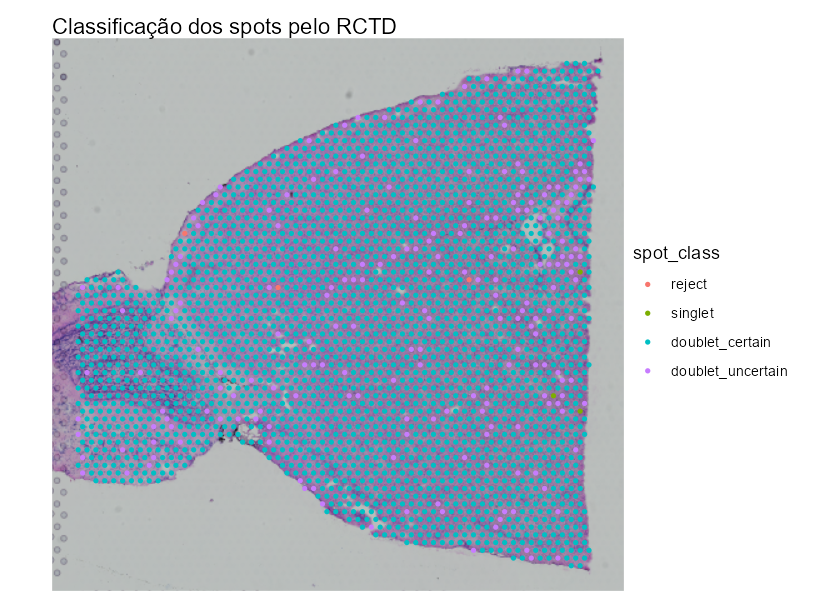

Classificação dos spots pelo RCTD.

Em seguida, visualize o primeiro e o segundo tipo celular atribuídos. O segundo tipo deve ser interpretado somente junto com `spot_class`: ele é confiável quando o spot foi classificado como `doublet_certain`.

```r
p1 <- Seurat::SpatialDimPlot(
  object = stxbrain,
  images = nome_imagem,
  group.by = "first_type",
  pt.size.factor = 1.6,
  crop = TRUE
) +
  labs(title = "Primeiro tipo celular")

p2 <- Seurat::SpatialDimPlot(
  object = stxbrain,
  images = nome_imagem,
  group.by = "second_type",
  pt.size.factor = 1.6,
  crop = TRUE
) +
  labs(title = "Segundo tipo celular")

p_tipos <- p1 + p2
p_tipos

ggplot2::ggsave(
  filename = file.path(
    diretorio_imagens,
    "rctd_primeiro_tipo_celular.png"
  ),
  plot = p1,
  width = 7,
  height = 5,
  units = "in",
  dpi = 120,
  bg = "white"
)

ggplot2::ggsave(
  filename = file.path(
    diretorio_imagens,
    "rctd_segundo_tipo_celular.png"
  ),
  plot = p2,
  width = 7,
  height = 5,
  units = "in",
  dpi = 120,
  bg = "white"
)

ggplot2::ggsave(
  filename = file.path(
    diretorio_imagens,
    "rctd_tipos_celulares_combinados.png"
  ),
  plot = p_tipos,
  width = 10,
  height = 5,
  units = "in",
  dpi = 120,
  bg = "white"
)

rm(p1, p2, p_tipos)
invisible(gc())
```

Os mapas individuais permitem examinar com mais detalhe a distribuição espacial de cada atribuição.

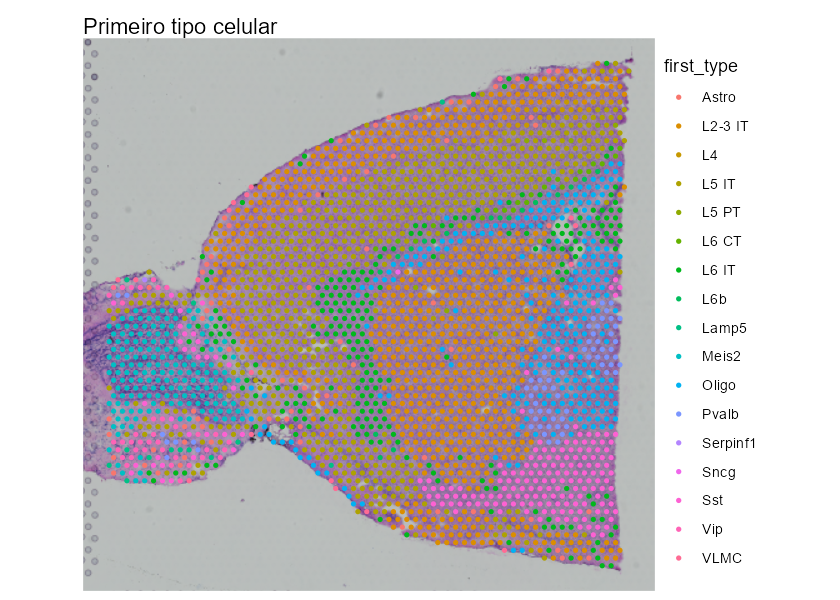

Primeiro tipo celular atribuído a cada spot.

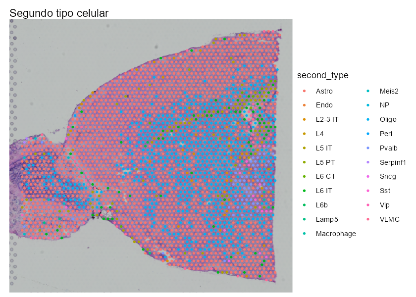

Segundo tipo celular atribuído a cada spot.

O painel combinado facilita a comparação direta entre o primeiro e o segundo tipo celular.

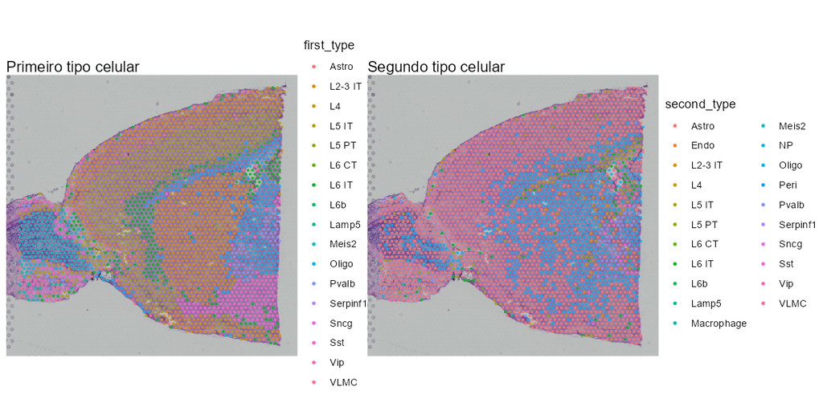

Comparação entre o primeiro e o segundo tipo celular atribuídos pelo RCTD.